# Toronto Mental Health and Policing Funding Figures and Statistics

Hana Dampf

June 3, 2020

## Motivation

I have neither the skillset nor experience to provide opinions and rhetoric on the facts I present here. I hope the statistics and figures I present have some use for my friends currently engaged in the conversation on police funding in Ontario started and led by anti-black racism and Indigenous activists.

## People in Crisis Calls

In Toronto, approx. 2-3%$^1$ of total calls dispatched annually by Toronto Police Service (TPS) were explicitly described as “Person in Crisis” (PIC) calls, defined as calls placed because of an apparent need for urgent care within the mental health system, or because they are otherwise experiencing a mental or emotional crisis leading to police involvement via a call to emergency services.$^2$

Calls defined this way, as reported by TPS, would not describe all encounters with a mental health component, but do describe encounters with people at increased risk of facing use of force and [deadly force](https://www.cbc.ca/news/investigates/most-canadians-killed-in-police-encounters-since-2000-had-mental-health-or-substance-abuse-issues-1.4602916).

The results of the 2012 Canadian Community Health Survey$^3$ indicated one fifth of all police encounters involved a Canadian with a mental health or substance use disorder.

## Mobile Crisis Response Team (MCIT)

Toronto Police Services has limited capacity to send an MCIT$^4$ (consisting of a police officer and registered nurse) to respond to PIC calls.

As of June 2020, MCIT officer teams are not available 24/7, but at most from 11:00am to 11:00pm. $^5$

Funding for the mental health nurses in these teams comes from the Toronto LHIN, not the TPS budget. $^6$

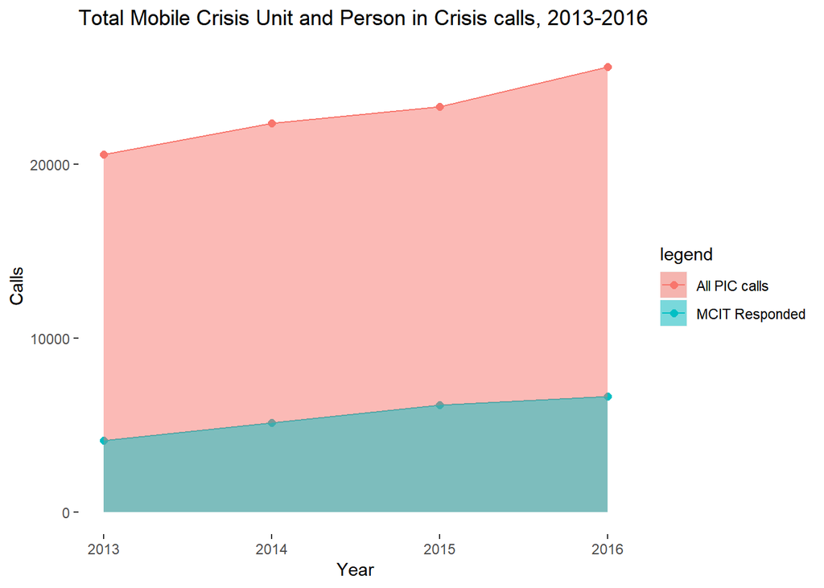

This figure displays the most recent data$^7$ I can find on MCIT calls in Toronto. While their capacity grew over the time frame, current policy $^8$ and funding levels mean less than a third of TPS calls explicitly labelled as a mental health crisis had a trained healthcare worker as a first responder.

## Toronto Police Services Funding

[This graph as an image file](https://hana-dampf.github.io/images/TPSFundingCompare.png)

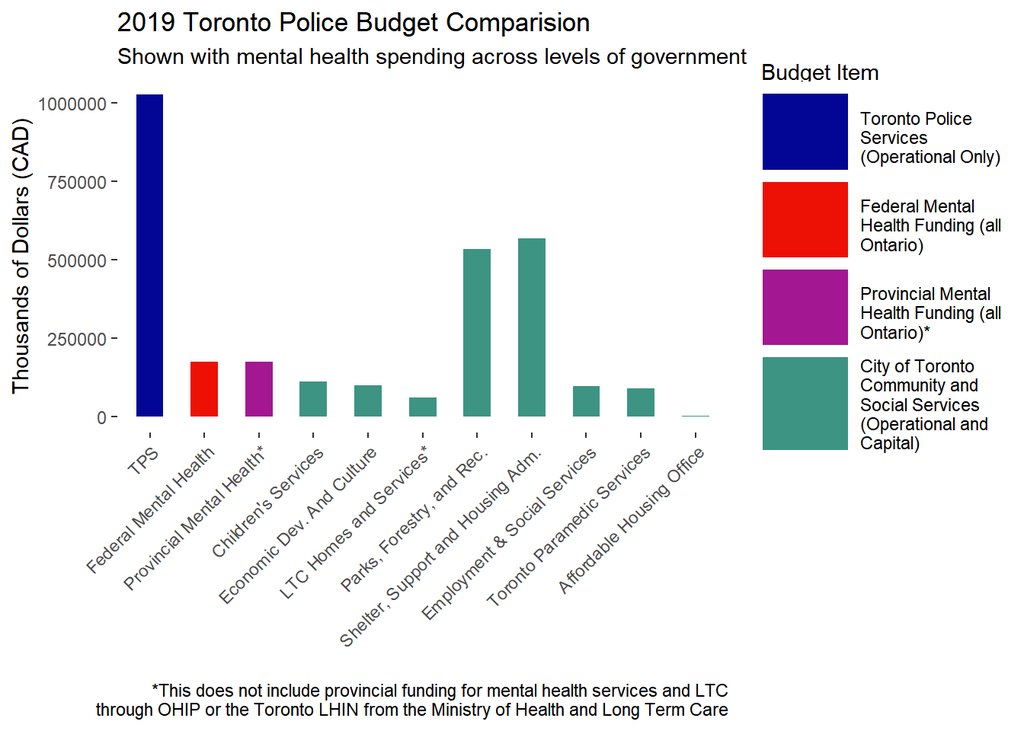

The Toronto Police Services operational budget was 1.026 billion dollars in 2019-20$^9$. It was by far the [largest item](https://www.toronto.ca/city-government/budget-finances/city-budget/basic-basics/how-your-tax-dollars-work/) in the City of Toronto Budget. This is compared to Federal$^{10}$ and Provincial$^{11}$ allotments of approx. 174 million each to directly fund mental health iniatives and services in 2019-20. I have also shown several other City of Toronto departments$^{12}$ to allow for funding comparisons.

## Police Practices and Race

It is extremely difficult to access data on this topic due to a lack of collection and release of data by TPS on interactions with racialised and Indigenous individuals. The police did start a data collection iniative in January 2020 on this topic which has no released results I can find as of June 2020.

Research and data collection on this topic in Toronto has largely been completed by journalists, academics and activists. When I was trying to find data to integrate here, these were the best resources I found:

[CBC Deadly Force Interactive](https://newsinteractives.cbc.ca/longform-custom/deadly-force)  
[Sociologist Akwasi Owusu-Bempah](https://www.utm.utoronto.ca/sociology/faculty-staff/owusu-bempah-akwasi)  
[Police Use of Force in Ontario Review](https://www.attorneygeneral.jus.gov.on.ca/inquiries/ipperwash/policy_part/projects/pdf/AfricanCanadianClinicIpperwashProject_SIUStudybyScotWortley.pdf)

## Footnotes

1. I verified this metric, reported in a few TPS press releases, across several years by using a numerator from $^6$ and a denominator from TPS statistical reports. source:https://www.torontopolice.on.ca/publications/files/reports/2016statsreport.pdf
2. (Iaccobucci, 2014) source:https://www.torontopolice.on.ca/publications/files/reports/police_encounters_with_people_in_crisis_2014.pdf
3. (Statistics Canada, 2015) source:https://www150.statcan.gc.ca/n1/pub/85-002-x/2015001/article/14176-eng.htm
4. (Lamanna et al, 2015) source:http://stmichaelshospitalresearch.ca/wp-content/uploads/2016/12/MCIT-outcome-evaluation-Final-report.pdf
5. (TPS, 2020) source:http://www.torontopolice.on.ca/community/mcit.php
6. (Global News, 2014) source:https://globalnews.ca/news/1311287/toronto-police-hospitals-to-expand-crisis-intervention-program/
7. (Human Services and Justice Coordinating Committees website, 2017) source:https://hsjcc.on.ca/wp-content/uploads/MCIT-Introduction-Presentation-Mar-2018-v2.pdf
8. The Toronto Police Service chief has stated that their risk assessment would not have allowed an MCIT team to respond to the call leading to the death of Regis Korchinski-Paquet (CP24, 2020) source:https://www.cp24.com/news/there-s-a-whole-lot-that-i-want-to-say-saunders-says-of-toronto-woman-s-fatal-fall-1.4960625
9. (CBC,2019) source:https://www.cbc.ca/news/canada/toronto/police-budget-1.5379373
10. (Government of Canada, 2019) source:https://www.canada.ca/en/health-canada/corporate/transparency/health-agreements/shared-health-priorities/ontario.html
11. (Government of Ontario,2019) source:https://budget.ontario.ca/2019/chapter-1c.html#s-12
12. (City of Toronto, 2019) source:https://www.toronto.ca/wp-content/uploads/2019/09/968e-2019-Toronto-Budget-Public-Book.pdf